# Untitled

2024-10-19

Per l’enunciat sabem que segueix una distribució gamma ja que funció de variància és $\mu^2$ i també sabem que el link es invers ja que $g(\mu)=\frac{1}{\mu}$

# Lectura de dades

```r
dades<-read.csv2("./SOLER CARBALLO, Àlex.csv",header=T,stringsAsFactors = TRUE)
colnames(dades)[2]<-"Temps"
#dades$Temps<-as.factor(dades$Temps)
```

# Evolució VitC només tenint en compte el Temps

# Descriptiva

```r
library("car")
```

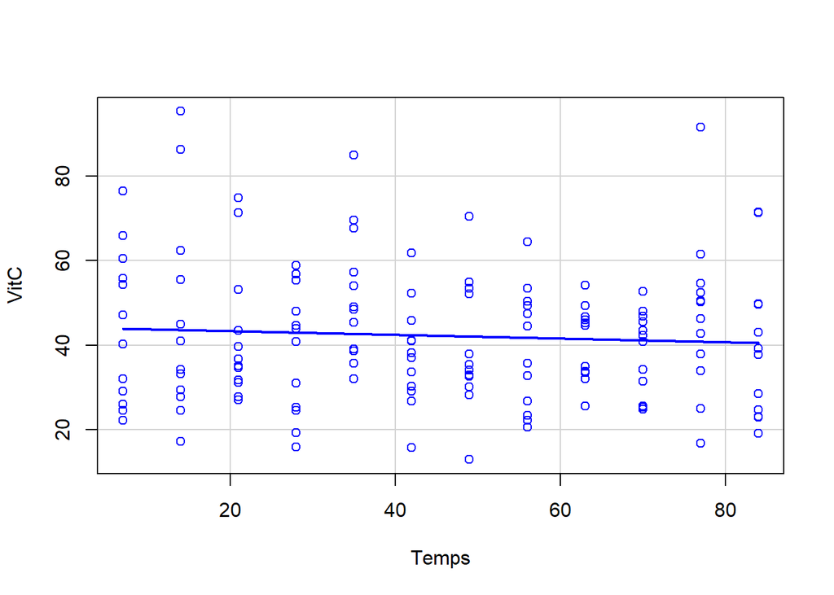

```r
sp(VitC ~ Temps, boxplot=FALSE, smooth=FALSE, dades)
```

# Model glm A amb VitC~Temps

```r
library(car)
glmA <- glm(VitC ~ Temps, family=Gamma(link=inverse),dades)
glmA0<-glm(VitC~1,family=Gamma(link=inverse),dades)
summary(glmA)
```

```
##
## Call:
## glm(formula = VitC ~ Temps, family = Gamma(link = inverse), data = dades)
##
## Coefficients:
##              Estimate Std. Error t value Pr(>|t|)
## (Intercept) 2.255e-02  1.557e-03  14.478   <2e-16 ***
## Temps       2.517e-05  3.089e-05   0.815    0.416
## ---
## Signif. codes:  0 '***' 0.001 '**' 0.01 '*' 0.05 '.' 0.1 ' ' 1
##
## (Dispersion parameter for Gamma family taken to be 0.1430294)
##
##     Null deviance: 20.580  on 143  degrees of freedom
## Residual deviance: 20.485  on 142  degrees of freedom
## AIC: 1194.7
##
## Number of Fisher Scoring iterations: 5
```

```r
anova(glmA0,glmA,test="F") #don p-valor>>>0.1, per tant, ens quedariem amb m10
```

```
## Analysis of Deviance Table
##
## Model 1: VitC ~ 1
## Model 2: VitC ~ Temps
##   Resid. Df Resid. Dev Df Deviance      F Pr(>F)
## 1       143     20.580
## 2       142     20.485  1 0.095031 0.6644 0.4164
```

```r
Anova(glmA,test="F") #contribució marginal, es veu que Temps no contribueix (pvalor>>>>0.1)
```

```
## Analysis of Deviance Table (Type II tests)
##
## Response: VitC
## Error estimate based on Pearson residuals
##
##           Sum Sq  Df F value Pr(>F)
## Temps      0.095   1  0.6644 0.4164
## Residuals 20.310 142
```

## 1) Paràmetre de dispersió

```r
signif(summary(glmA)$dispersion,5)
```

```
## [1] 0.14303
```

## 2) Quan T=0, estimacio predictor lineal és

type=“link”

```r
pred_link <- predict.glm(object  = glmA,
                     newdata = data.frame(Temps=0),
                     se.fit  = TRUE, #aqui diem que ens calculi IC (aixo per mitjana)
                     type    = "link")
signif(pred_link$fit,5)
```

```
##        1
## 0.022548
```

## 3) Quan T=0, estimacio parametre canònic theta és

```r
signif(-pred_link$fit,5)
```

```
##         1
## -0.022548
```

## 4) Estimacio E(VitC|T=47) ha donat:

“response”

```r
pred_response <- predict.glm(object  = glmA,
                     newdata = data.frame(Temps=47),
                     se.fit  = TRUE, #aqui diem que ens calculi IC (aixo per mitjana)
                     type    = "response")
signif(pred_response$fit,5)
```

```
##      1
## 42.138
```

## 5) Estimació Var(VitC|T=47)=dispersio*V(mu_i) ha donat:

```r
signif(summary(glmA)$dispersio*pred_response$fit^2,5)
```

```
##      1
## 253.97
```

# Model glmB amb VitC~Tract+Temps

```r
glmB <- glm(VitC ~ Tract+Temps, family=Gamma(link=inverse),dades)
summary(glmB)
```

```
##
## Call:
## glm(formula = VitC ~ Tract + Temps, family = Gamma(link = inverse),
##     data = dades)
##
## Coefficients:
##               Estimate Std. Error t value Pr(>|t|)
## (Intercept)  2.459e-02  1.946e-03  12.635  < 2e-16 ***
## Tractb       3.421e-03  2.254e-03   1.518  0.13137
## Tractc      -3.560e-03  1.968e-03  -1.808  0.07269 .
## Tractd      -5.883e-03  1.883e-03  -3.124  0.00217 **
## Temps        2.466e-05  2.816e-05   0.876  0.38274
## ---
## Signif. codes:  0 '***' 0.001 '**' 0.01 '*' 0.05 '.' 0.1 ' ' 1
##
## (Dispersion parameter for Gamma family taken to be 0.1213637)
##
##     Null deviance: 20.580  on 143  degrees of freedom
## Residual deviance: 17.429  on 139  degrees of freedom
## AIC: 1176.9
##
## Number of Fisher Scoring iterations: 5
```

## 6) Paràmetre de dispersió

```r
signif(summary(glmB)$dispersion,5)
```

```
## [1] 0.12136
```

## 7) Quan T=65 i Tract=b, l’estimació del predictor lineal és:

type=“link”

```r
pred_linkB <- predict.glm(object  = glmB,
                     newdata = data.frame(Tract="b",Temps=65),
                     se.fit  = TRUE, #aqui diem que ens calculi IC (aixo per mitjana)
                     type    = "link")
signif(pred_linkB$fit,5)
```

```
##       1
## 0.02961
```

## 8) E(VitC|T=65,Tract=b) és

type=“response”

```r
pred_responseB <- predict.glm(object  = glmB,
                     newdata = data.frame(Tract="b",Temps=65),
                     se.fit  = TRUE, #aqui diem que ens calculi IC (aixo per mitjana)
                     type    = "response")
signif(pred_responseB$fit,5)
```

```
##      1
## 33.773
```

## 9) L’estimació de la desviació tipus S(VitC|T=65,Tract=b) és

```r
signif(sqrt(summary(glmB)$dispersio*pred_responseB$fit^2),5)
```

```
##      1
## 11.765
```

## 10) Valor deviància model glmB

```r
signif(summary(glmB)$deviance,5)
```

```
## [1] 17.429
```

# Model glmC VitC~Tract*Temps

```r
glmC <- glm(VitC ~ Tract*Temps, family=Gamma(link=inverse),dades)
summary(glmC)
```

```
##
## Call:
## glm(formula = VitC ~ Tract * Temps, family = Gamma(link = inverse),
##     data = dades)
##
## Coefficients:
##                Estimate Std. Error t value Pr(>|t|)
## (Intercept)   1.864e-02  2.716e-03   6.864 2.17e-10 ***
## Tractb        1.607e-02  4.680e-03   3.433 0.000791 ***
## Tractc        1.162e-03  3.726e-03   0.312 0.755671
## Tractd        1.982e-03  3.650e-03   0.543 0.588068
## Temps         1.692e-04  6.080e-05   2.783 0.006157 **
## Tractb:Temps -2.861e-04  9.162e-05  -3.123 0.002190 **
## Tractc:Temps -1.164e-04  8.000e-05  -1.455 0.147879
## Tractd:Temps -1.869e-04  7.653e-05  -2.443 0.015865 *
## ---
## Signif. codes:  0 '***' 0.001 '**' 0.01 '*' 0.05 '.' 0.1 ' ' 1
##
## (Dispersion parameter for Gamma family taken to be 0.1157692)
##
##     Null deviance: 20.580  on 143  degrees of freedom
## Residual deviance: 16.144  on 136  degrees of freedom
## AIC: 1171.7
##
## Number of Fisher Scoring iterations: 5
```

## 11) Paràmetre de dispersió

```r
signif(summary(glmC)$dispersion,5)
```

```
## [1] 0.11577
```

## 12) Valor estadístic de contrast per comparar glmB amb glmC és

Per calcular-ho manualment seria ((summary(glmB)$deviance-summary(glmC)$deviance)/summary(glmC)$dispersion)/(8-5)

```r
#Per calcular-ho manualment seria
#((summary(glmB)$deviance-summary(glmC)$deviance)/summary(glmC)$dispersion)/(8-5)
((summary(glmB)$deviance-summary(glmC)$deviance)/summary(glmC)$dispersion)/(8-5) #on 8 numero params glmC i 5 numeros params glmB
```

```
## [1] 3.699724
```

```r
anova(glmB,glmC,test="F")
```

```
## Analysis of Deviance Table
##
## Model 1: VitC ~ Tract + Temps
## Model 2: VitC ~ Tract * Temps
##   Resid. Df Resid. Dev Df Deviance      F  Pr(>F)
## 1       139     17.429
## 2       136     16.144  3   1.2849 3.6997 0.01341 *
## ---
## Signif. codes:  0 '***' 0.001 '**' 0.01 '*' 0.05 '.' 0.1 ' ' 1
```

```r
signif(anova(glmB,glmC,test="F")$F[2],5)
```

```
## [1] 3.6997
```

## 13) Quan T=56 i Tract=a, l’extrem superior de l’interval de confiança (95%) del predictor lineal és (aproximació Normal)

```r
pred_linkC <- predict.glm(object  = glmC,
                     newdata = data.frame(Tract="a",Temps=56),
                     se.fit  = TRUE,
                     type    = "link")
signif(pred_linkC$fit+qnorm(0.975)*pred_linkC$se.fit,5)
```

```
##        1
## 0.031668
```

## 14) L’extrem inferior de l’interval de confiança (95%) de E(VitC|T=56,Tract=a) és (aproximació t-Student)

```r
df<-glmC$df.residual
pred_responseC <- predict.glm(object  = glmC,
                     newdata = data.frame(Tract="a",Temps=56),
                     se.fit  = TRUE,
                     type    = "response")

signif(pred_responseC$fit - qt(0.975,df) * pred_responseC$se.fit,5)
```

```
##      1
## 31.034
```

# Model glmD VitC~Tract*Temps pero que tingui en compte que quan T=0 tractament no ha pogut tenir efecte sobre VitC, és a dir, que els paràmetres Beta0,i son tots quatre iguals

```r
glmD<-glm(VitC~Temps+Tract:Temps,family=Gamma(link=inverse),dades)
summary(glmD)
```

```
##
## Call:
## glm(formula = VitC ~ Temps + Tract:Temps, family = Gamma(link = inverse),
##     data = dades)
##
## Coefficients:
##                Estimate Std. Error t value Pr(>|t|)
## (Intercept)   2.232e-02  1.458e-03  15.316  < 2e-16 ***
## Temps         1.009e-04  4.235e-05   2.383 0.018532 *
## Temps:Tractb -6.464e-06  4.645e-05  -0.139 0.889521
## Temps:Tractc -9.221e-05  4.229e-05  -2.180 0.030906 *
## Temps:Tractd -1.472e-04  3.986e-05  -3.692 0.000319 ***
## ---
## Signif. codes:  0 '***' 0.001 '**' 0.01 '*' 0.05 '.' 0.1 ' ' 1
##
## (Dispersion parameter for Gamma family taken to be 0.1262757)
##
##     Null deviance: 20.580  on 143  degrees of freedom
## Residual deviance: 17.937  on 139  degrees of freedom
## AIC: 1181.2
##
## Number of Fisher Scoring iterations: 5
```

## 15) Paràmetre de dispersió

```r
signif(summary(glmD)$dispersion,5)
```

```
## [1] 0.12628
```

## 16) Valor estadístic de contrast per comparar glmC amb glmD es

```r
signif(anova(glmC,glmD,test="F")$F[2],5)
```

```
## [1] 5.1626
```

## 17) E(VitC|T=39,Tract=b)

```r
pred_responseD <- predict.glm(object  = glmD,
                     newdata = data.frame(Tract="b",Temps=39),
                     se.fit  = TRUE,
                     type    = "response")
pred_responseD$fit
```

```
##       1
## 38.4508
```

## 18) Quan Tract=b, el pendent del predictor lineal respecte a T és

```r
a<-summary(glmD)$coefficients
signif(a[2,1]+a[3,1],5)
```

```
## [1] 9.4452e-05
```

## 19) Escolliu entre glmC i glmD, el model que considereu millor per a les vostres dades.

```r
anova(glmD,glmC,test="F") #surt pvalor significatiu per tant agafarem model mes complet que es glmC
```

```
## Analysis of Deviance Table
##
## Model 1: VitC ~ Temps + Tract:Temps
## Model 2: VitC ~ Tract * Temps
##   Resid. Df Resid. Dev Df Deviance      F   Pr(>F)
## 1       139     17.937
## 2       136     16.144  3    1.793 5.1626 0.002071 **
## ---
## Signif. codes:  0 '***' 0.001 '**' 0.01 '*' 0.05 '.' 0.1 ' ' 1
```

## 20) Quin es el pvalor del test que heu contrastat per contestar la pregunta anterior

```r
signif(anova(glmC,glmD,test="F")$`Pr(>F)`[2],5)
```

```
## [1] 0.0020714
```

## 21) M pertany {a,b,c,d}. El tractament en el que ha sortit que la VitC baixa més ràpidament es

```r
library(emmeans)
library(multcomp)
(emmC  <- emmeans(glmC, ~Tract*Temps, type = "response"))
```

```
##  Tract Temps response   SE  df lower.CL upper.CL
##  a      45.5     38.0 2.18 136     34.1     42.8
##  b      45.5     34.0 1.94 136     30.6     38.3
##  c      45.5     45.0 2.56 136     40.5     50.7
##  d      45.5     50.5 2.86 136     45.4     56.8
##
## Confidence level used: 0.95
## Intervals are back-transformed from the inverse scale
```

```r
cld(emmC, Letters=letters,reversed = TRUE) #veiem que d-c; c-a; a-b
```

```
##  Tract Temps response   SE  df lower.CL upper.CL .group
##  d      45.5     50.5 2.86 136     45.4     56.8  a
##  c      45.5     45.0 2.56 136     40.5     50.7  ab
##  a      45.5     38.0 2.18 136     34.1     42.8   bc
##  b      45.5     34.0 1.94 136     30.6     38.3    c
##
## Confidence level used: 0.95
## Intervals are back-transformed from the inverse scale
## Note: contrasts are still on the inverse scale. Consider using
##       regrid() if you want contrasts of back-transformed estimates.
## P value adjustment: tukey method for comparing a family of 4 estimates
## significance level used: alpha = 0.05
## NOTE: If two or more means share the same grouping symbol,
##       then we cannot show them to be different.
##       But we also did not show them to be the same.
```

```r
#el que tiene una respuesta más baja es el tratamiento b, pero vemos que a y b pertenecen al mismo grupo, por tanto no hay diferencia estadistica y podriamos elegir que cualquiera de los dos es el mas bajo
```

Aqui estem calculan les tendencies (pendent) pels diferents tractaments. Com nosaltres tenim que mu=1/model, llavors haurem d’agafar el trends mes alt pq farà la fracció més petita. En aquest cas es el a

```r
emtrends(glmC,"Tract",var="Temps")
```

```
##  Tract Temps.trend       SE  df  lower.CL upper.CL
##  a        1.69e-04 6.08e-05 136  4.90e-05 2.89e-04
##  b       -1.17e-04 6.85e-05 136 -2.52e-04 1.86e-05
##  c        5.28e-05 5.20e-05 136 -5.01e-05 1.56e-04
##  d       -1.78e-05 4.65e-05 136 -1.10e-04 7.42e-05
##
## Confidence level used: 0.95
```

## 22) Anomenem 𝑚𝜖{𝑎, 𝑏, 𝑐, 𝑑} el tractament en que la E(VitC|T=84, Tract=m) ha sortit més baixa. En aquest cas E(VitC|T=84, Tract=m)

```r
pred_responseC1 <- predict.glm(object  = glmC,
                     newdata = data.frame(Tract="a",Temps=84),
                     se.fit  = TRUE,
                     type    = "response")
pred_responseC2 <- predict.glm(object  = glmC,
                     newdata = data.frame(Tract="b",Temps=84),
                     se.fit  = TRUE,
                     type    = "response")
pred_responseC3 <- predict.glm(object  = glmC,
                     newdata = data.frame(Tract="c",Temps=84),
                     se.fit  = TRUE,
                     type    = "response")
pred_responseC4 <- predict.glm(object  = glmC,
                     newdata = data.frame(Tract="d",Temps=84),
                     se.fit  = TRUE,
                     type    = "response")
dataf<-data.frame(Tract=c("a","b","c","d"),Valor=c(pred_responseC1$fit,pred_responseC2$fit,pred_responseC3$fit,pred_responseC4$fit))
dataf[which.min(dataf$Valor),]
```

```
##   Tract    Valor
## 1     a 30.43732
```

```r
signif(dataf[which.min(dataf$Valor),2],5)
```

```
## [1] 30.437
```